# Measuring Importance of Diplay and Feature Promotions for FMCG Brands with SCAN*PRO Model

Yousef Khalil - 02183384

April 25, 2022

# Introduction

Consumer brands invest significant time and resources to promote their products with advertisements and in-store promotions. It is important for these companies to measure the effect of their marketing activities on their sales to optimize their revenues. It is also useful to build models which can accurately forecast sales as a function of promotions. Brands in the fast moving consumer goods (FMCG) industry particularly benefit from these practices as it is a very competitive industry with millions of products sold. Companies such as P&G, Unilever, and KraftHeinz need to develop accurate and reliable models to forecast sales and tailor their in-store promotional strategies. The SCAN*PRO model performs well under such tasks.

# Data

## Dataset

The dataset ([Source](https://www.dunnhumby.com/)) used in this report contains display and feature promotion information for products from competing brand labels across four product categories: packaged snacks, cereals, frozen pizza, and oral hygiene products. The sales and price figures were collected from multiple stores over a period of 156 weeks ranging from January 2009 to January 2012.

The initial file contained a relational database of 3 tables: products, transactions, and stores. The products table contained information about the descriptions, manufacturers, and categories of each unique product and is linked to the transactions table through the universal product code (UPC) key. The transactions table contained all products purchased across the stores with their base prices, selling prices, and information on whether they were under feature or display promotions. The store table contains information on the consumer segment each store appeals to most: mainstream, value, and upscale. The two tables initially looked as follows:

Products Table

| UPC | DESCRIPTION | MANUFACTURER | CATEGORY | SUB_CATEGORY | PRODUCT_SIZE |
| --- | --- | --- | --- | --- | --- |
| 1111009477 | PL MINI TWIST PRETZELS | PRIVATE LABEL | BAG SNACKS | PRETZELS | 15 OZ |
| 1111009497 | PL PRETZEL STICKS | PRIVATE LABEL | BAG SNACKS | PRETZELS | 15 OZ |
| 1111009507 | PL TWIST PRETZELS | PRIVATE LABEL | BAG SNACKS | PRETZELS | 15 OZ |
| 1111035398 | PL BL MINT ANTSPTC RINSE | PRIVATE LABEL | ORAL HYGIENE PRODUCTS | MOUTHWASHES (ANTISEPTIC) | 1.5 LT |
| 1111038078 | PL BL MINT ANTSPTC RINSE | PRIVATE LABEL | ORAL HYGIENE PRODUCTS | MOUTHWASHES (ANTISEPTIC) | 500 ML |
| 1111038080 | PL ANTSPTC SPG MNT MTHWS | PRIVATE LABEL | ORAL HYGIENE PRODUCTS | MOUTHWASHES (ANTISEPTIC) | 500 ML |

Transactions Table

| WEEK_END_DATE | STORE_NUM | UPC | UNITS | VISITS | HHS | SPEND | PRICE | BASE_PRICE | FEATURE | DISPLAY | TPR_ONLY |
| --- | --- | --- | --- | --- | --- | --- | --- | --- | --- | --- | --- |
| 2009-01-14 | 367 | 1111009477 | 13 | 13 | 13 | 18.07 | 1.39 | 1.57 | 0 | 0 | 1 |
| 2009-01-14 | 367 | 1111009497 | 20 | 18 | 18 | 27.80 | 1.39 | 1.39 | 0 | 0 | 0 |
| 2009-01-14 | 367 | 1111009507 | 14 | 14 | 14 | 19.32 | 1.38 | 1.38 | 0 | 0 | 0 |
| 2009-01-14 | 367 | 1111035398 | 4 | 3 | 3 | 14.00 | 3.50 | 4.49 | 0 | 0 | 1 |
| 2009-01-14 | 367 | 1111038078 | 3 | 3 | 3 | 7.50 | 2.50 | 2.50 | 0 | 0 | 0 |
| 2009-01-14 | 367 | 1111038080 | 2 | 2 | 2 | 5.18 | 2.59 | 2.59 | 0 | 0 | 0 |

Our main variables of concern from both tables are:

**WEEK_END_DATE:** the last day of the week of transaction

**UPC:** unique identifier key for each product

**CATEGORY:** category of product (snacks, cereal,…)

**MANUFACTURER:** brand

**FEATURE:** binary variable equal to 1 if product had a feature promotion at the time of transaction, 0 otherwise.

**DISPLAY:** binary variable equal to 1 if product had a display promotion at the time of transaction, 0 otherwise.

**PRICE:** price item was sold at

**UNITS:** number of units sold in the transaction

**STORE_NUM:** store number

**SEG_VALUE_NAME:** customer segment which store appeals to

## Data Processing

### Missing Values

Upon close inspection of both tables, the only source of missing records within the variables of concern is the **PRICE** column in the transactions table. All missing price values have non-missing base prices, and are neither featured nor displayed. Therefore, the selling price of these products must be equal to their base price. So, we assign a **PRICE** value to these entries equal to their base price.

Missing Prices

| UPC | PRICE | DISPLAY | FEATURE | STORE_NUM |
| --- | --- | --- | --- | --- |
| 1111038078 | NA | 0 | 0 | 25001 |
| 1111038080 | NA | 0 | 0 | 25001 |
| 1111087396 | NA | 0 | 0 | 11761 |
| 3700019521 | NA | 0 | 0 | 23055 |
| 31254742835 | NA | 0 | 0 | 6187 |
| 31254742735 | NA | 0 | 0 | 28909 |

### Processing

The second data processing step is to join the transactions and products table. We do a left join on the common key **UPC** since we want to preserve all transaction. Then, we join the resulting table with the stores table using the **STORE_ID** key.

Our goal is to do a separate analysis of each category and its brands, so we proceed by dividing the resulting dataframe by category. This will result in 4 different dataframes, 1 for each category. We also want to account for the differences in sales across stores for each brand. However, we have 79 different stores and including all of them in the SCAN*PRO model is problematic (will have to include 78 dummy variables). Since we have information on the typical customer segments whom each store appeals to, we can conduct our analysis on the type of store rather than differentiate between each of the 79 stores. We have 3 types of stores: mainstream, value, and upscale. We only need to include a dummy variable for 2 types so we create a dummy variable for mainstream and upscale stores.

Each brand also has multiple similar products within one category. To simplify our analysis, we will average all the products of a brand into one product. To achieve this, we group the data by week, manufacturer, and the created store dummy variables and then compute a weighted average of price for products of the same brand with the units sold as weights. We also compute the total number of units sold and multiply it by the weighted average price to get the total sales. We will assume that a brand is running a feature or display promotion if it has ran a feature or display for at least one of its products. Therefore, we compute DISPLAY = max(DISPLAY) and FEATURE=max(FEATURE) as an aggregate metric. The resulting data is as follows:

```r
# Data Processing

# Handle missing data and join tables
data_final <- transactions %>%
  mutate(PRICE=if_else(is.na(PRICE) & FEATURE==0,
                       BASE_PRICE,
                       PRICE)) %>%
  rename(STORE_ID=STORE_NUM) %>%
  left_join(products,by="UPC") %>%
  left_join(stores,by="STORE_ID") %>%
  mutate(DISPL_FEATURE=if_else(DISPLAY==1 & FEATURE==1,1,0),
         MAINSTREAM=if_else(SEG_VALUE_NAME=="MAINSTREAM",1,0),
         UPSCALE=if_else(SEG_VALUE_NAME=="UPSCALE",1,0)) %>%
  select(WEEK_END_DATE,UPC,UNITS,PRICE, FEATURE, DISPLAY, DISPL_FEATURE, MANUFACTURER,CATEGORY,SEG_VALUE_NAME,MAINSTREAM, UPSCALE)


# Divide the datasets by product categories

# Packed snacks
snacks <- data_final %>%
  filter(CATEGORY=="BAG SNACKS") %>%
  group_by(WEEK_END_DATE,MANUFACTURER,UPSCALE,MAINSTREAM) %>%
  summarise(W_AVG_PRICE=weighted.mean(PRICE,UNITS),
            TOTAL_UNITS=sum(UNITS),
            SALES=TOTAL_UNITS*W_AVG_PRICE,
            DISPLAY=max(DISPLAY),
            FEATURE=max(FEATURE),
            DISPL_FEATURE=max(DISPL_FEATURE))

# Cereal Products
cereal <- data_final %>%
  filter(CATEGORY=="COLD CEREAL") %>%
  group_by(WEEK_END_DATE,MANUFACTURER,UPSCALE,MAINSTREAM) %>%
  summarise(W_AVG_PRICE=weighted.mean(PRICE,UNITS),
            TOTAL_UNITS=sum(UNITS),
            SALES=TOTAL_UNITS*W_AVG_PRICE,
            DISPLAY=max(DISPLAY),
            FEATURE=max(FEATURE),
            DISPL_FEATURE=max(DISPL_FEATURE))

# Frozen Pizza
pizza <- data_final %>%
  filter(CATEGORY=="FROZEN PIZZA") %>%
  group_by(WEEK_END_DATE,MANUFACTURER,UPSCALE,MAINSTREAM) %>%
  summarise(W_AVG_PRICE=weighted.mean(PRICE,UNITS),
            TOTAL_UNITS=sum(UNITS),
            SALES=TOTAL_UNITS*W_AVG_PRICE,
            DISPLAY=max(DISPLAY),
            FEATURE=max(FEATURE),
            DISPL_FEATURE=max(DISPL_FEATURE))

# Oral Hygiene Products
oral <- data_final %>%
  filter(CATEGORY=="ORAL HYGIENE PRODUCTS") %>%
  group_by(WEEK_END_DATE,MANUFACTURER,UPSCALE,MAINSTREAM) %>%
  summarise(W_AVG_PRICE=weighted.mean(PRICE,UNITS),
            TOTAL_UNITS=sum(UNITS),
            SALES=TOTAL_UNITS*W_AVG_PRICE,
            DISPLAY=max(DISPLAY),
            FEATURE=max(FEATURE),
            DISPL_FEATURE=max(DISPL_FEATURE))

head(snacks) %>% kbl(caption="Snack Products") %>%   kable_paper("hover", full_width = F)
```

Snack Products

| WEEK_END_DATE | MANUFACTURER | UPSCALE | MAINSTREAM | W_AVG_PRICE | TOTAL_UNITS | SALES | DISPLAY | FEATURE | DISPL_FEATURE |
| --- | --- | --- | --- | --- | --- | --- | --- | --- | --- |
| 2009-01-14 | FRITO LAY | 0 | 0 | 2.638235 | 170 | 448.50 | 0 | 0 | 0 |
| 2009-01-14 | FRITO LAY | 0 | 1 | 2.653154 | 1319 | 3499.51 | 1 | 0 | 0 |
| 2009-01-14 | FRITO LAY | 1 | 0 | 2.642766 | 1139 | 3010.11 | 0 | 0 | 0 |
| 2009-01-14 | MKSL | 0 | 0 | 2.500000 | 34 | 85.00 | 0 | 0 | 0 |
| 2009-01-14 | MKSL | 0 | 1 | 2.502622 | 225 | 563.09 | 0 | 0 | 0 |
| 2009-01-14 | MKSL | 1 | 0 | 2.502281 | 114 | 285.26 | 0 | 0 | 0 |

```r
head(cereal) %>% kbl(caption="Cereal Products") %>%   kable_paper("hover", full_width = F)
```

Cereal Products

| WEEK_END_DATE | MANUFACTURER | UPSCALE | MAINSTREAM | W_AVG_PRICE | TOTAL_UNITS | SALES | DISPLAY | FEATURE | DISPL_FEATURE |
| --- | --- | --- | --- | --- | --- | --- | --- | --- | --- |
| 2009-01-14 | GENERAL MI | 0 | 0 | 3.202503 | 1594 | 5104.79 | 1 | 1 | 0 |
| 2009-01-14 | GENERAL MI | 0 | 1 | 3.073839 | 5639 | 17333.38 | 1 | 1 | 0 |
| 2009-01-14 | GENERAL MI | 1 | 0 | 3.108971 | 3217 | 10001.56 | 0 | 1 | 0 |
| 2009-01-14 | KELLOGG | 0 | 0 | 2.826768 | 2203 | 6227.37 | 1 | 1 | 1 |
| 2009-01-14 | KELLOGG | 0 | 1 | 2.864312 | 4423 | 12668.85 | 1 | 1 | 1 |
| 2009-01-14 | KELLOGG | 1 | 0 | 2.906130 | 2018 | 5864.57 | 1 | 1 | 1 |

```r
head(pizza) %>% kbl(caption="Pizza Products") %>%   kable_paper("hover", full_width = F)
```

Pizza Products

| WEEK_END_DATE | MANUFACTURER | UPSCALE | MAINSTREAM | W_AVG_PRICE | TOTAL_UNITS | SALES | DISPLAY | FEATURE | DISPL_FEATURE |
| --- | --- | --- | --- | --- | --- | --- | --- | --- | --- |
| 2009-01-14 | PRIVATE LABEL | 0 | 0 | 3.304451 | 1822 | 6020.71 | 1 | 1 | 0 |
| 2009-01-14 | PRIVATE LABEL | 0 | 1 | 3.300542 | 3264 | 10772.97 | 1 | 0 | 0 |
| 2009-01-14 | PRIVATE LABEL | 1 | 0 | 3.292855 | 802 | 2640.87 | 1 | 0 | 0 |
| 2009-01-14 | TOMBSTONE | 0 | 0 | 6.013701 | 1043 | 6272.29 | 1 | 1 | 1 |
| 2009-01-14 | TOMBSTONE | 0 | 1 | 5.981249 | 2498 | 14941.16 | 1 | 1 | 1 |
| 2009-01-14 | TOMBSTONE | 1 | 0 | 6.007064 | 1073 | 6445.58 | 1 | 1 | 1 |

```r
head(oral) %>% kbl(caption="Oral Hygiene Products") %>%   kable_paper("hover", full_width = F)
```

Oral Hygiene Products

| WEEK_END_DATE | MANUFACTURER | UPSCALE | MAINSTREAM | W_AVG_PRICE | TOTAL_UNITS | SALES | DISPLAY | FEATURE | DISPL_FEATURE |
| --- | --- | --- | --- | --- | --- | --- | --- | --- | --- |
| 2009-01-14 | CHATTEM | 0 | 0 | 4.230385 | 52 | 219.98 | 0 | 0 | 0 |
| 2009-01-14 | CHATTEM | 0 | 1 | 4.231322 | 363 | 1535.97 | 1 | 0 | 0 |
| 2009-01-14 | CHATTEM | 1 | 0 | 4.299324 | 222 | 954.45 | 0 | 0 | 0 |
| 2009-01-14 | P & G | 0 | 0 | 3.684914 | 175 | 644.86 | 1 | 0 | 0 |
| 2009-01-14 | P & G | 0 | 1 | 3.492964 | 739 | 2581.30 | 1 | 0 | 0 |
| 2009-01-14 | P & G | 1 | 0 | 3.243022 | 503 | 1631.24 | 1 | 0 | 0 |

## Exploratory Visualizations

We first conduct exploratory data analysis to examine the relationship between price, sales, features, and displays. For each product category, we create bar charts to compare sales, average price, total features, and total displays between the manufacturers. This allows us to have a preliminary idea of the consumer behavior and preferences within each product category.

### Snack

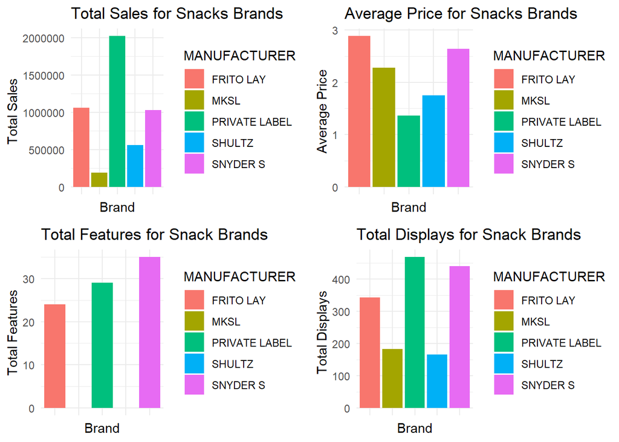

```r
theme_set(theme_minimal())

p1 <- snacks %>% group_by(MANUFACTURER) %>%
  summarise(TOTAL_SALES=sum(SALES)) %>%
  ggplot()+
  geom_bar(aes(x=MANUFACTURER, y=TOTAL_SALES, fill=MANUFACTURER), stat="identity")+
    labs(title="Total Sales for Snacks Brands",
       x= "Brand",
       y="Total Sales") +
  theme(axis.ticks.x = element_blank(),
        axis.text.x = element_blank())

p2 <- snacks %>% group_by(MANUFACTURER) %>%
  summarise(AVG_PRICE=mean(W_AVG_PRICE)) %>%
  ggplot()+
  geom_bar(aes(x=MANUFACTURER, y=AVG_PRICE, fill=MANUFACTURER), stat="identity")+
    labs(title="Average Price for Snacks Brands",
       x= "Brand",
       y="Average Price")+
  theme(axis.ticks.x = element_blank(),
        axis.text.x = element_blank())

p3 <- snacks %>% group_by(MANUFACTURER) %>%
  summarise(TOTAL_FEATURES=sum(FEATURE)) %>%
  ggplot()+
  geom_bar(aes(x=MANUFACTURER, y=TOTAL_FEATURES, fill=MANUFACTURER),
           stat="identity")+
   labs(title="Total Features for Snack Brands",
       x= "Brand",
       y="Total Features")+
  theme(axis.ticks.x = element_blank(),
        axis.text.x = element_blank())

p4 <- snacks %>% group_by(MANUFACTURER) %>%
  summarise(TOTAL_DISPLAYS=sum(DISPLAY)) %>%
  ggplot()+
  geom_bar(aes(x=MANUFACTURER, y=TOTAL_DISPLAYS, fill=MANUFACTURER),
           stat="identity")+
   labs(title="Total Displays for Snack Brands",
       x= "Brand",
       y="Total Displays")+
  theme(axis.ticks.x = element_blank(),
        axis.text.x = element_blank())


grid.arrange(p1,p2,p3,p4,nrow=2)
```

We can deduce from the above figures that consumers of snack products generally lean more towards less expensive, featured snacks. They are more price conscious than brand conscious. This is likely because there is more product homogeneity within the snacks categories as the products taste similar and more expensive snacks can be substituted with cheaper brands.

### Cereal

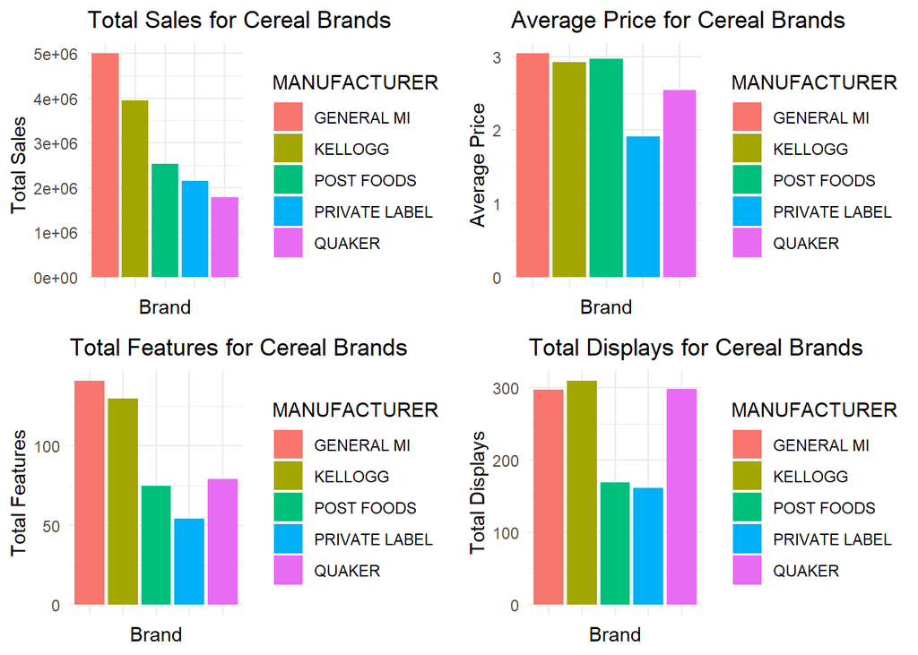

```r
p1 <- cereal %>% group_by(MANUFACTURER) %>%
  summarise(TOTAL_SALES=sum(SALES)) %>%
  ggplot()+
  geom_bar(aes(x=MANUFACTURER, y=TOTAL_SALES, fill=MANUFACTURER),
           stat="identity") +
   labs(title="Total Sales for Cereal Brands",
       x= "Brand",
       y="Total Sales")+
  theme(axis.ticks.x = element_blank(),
        axis.text.x = element_blank())

p2 <- cereal %>% group_by(MANUFACTURER) %>%
  summarise(AVG_PRICE=mean(W_AVG_PRICE)) %>%
  ggplot()+
  geom_bar(aes(x=MANUFACTURER, y=AVG_PRICE, fill=MANUFACTURER), stat="identity")+
    labs(title="Average Price for Cereal Brands",
       x= "Brand",
       y="Average Price")+
  theme(axis.ticks.x = element_blank(),
        axis.text.x = element_blank())

p3 <- cereal %>% group_by(MANUFACTURER) %>%
  summarise(TOTAL_FEATURES=sum(FEATURE)) %>%
  ggplot()+
  geom_bar(aes(x=MANUFACTURER, y=TOTAL_FEATURES, fill=MANUFACTURER),
           stat="identity")+
   labs(title="Total Features for Cereal Brands",
       x= "Brand",
       y="Total Features")+
  theme(axis.ticks.x = element_blank(),
        axis.text.x = element_blank())

p4 <- cereal %>% group_by(MANUFACTURER) %>%
  summarise(TOTAL_DISPLAYS=sum(DISPLAY)) %>%
  ggplot()+
  geom_bar(aes(x=MANUFACTURER, y=TOTAL_DISPLAYS, fill=MANUFACTURER),
           stat="identity")+
   labs(title="Total Displays for Cereal Brands",
       x= "Brand",
       y="Total Displays")+
  theme(axis.ticks.x = element_blank(),
        axis.text.x = element_blank())

grid.arrange(p1,p2,p3,p4,nrow=2)
```

The same analysis for the cereal category tells a different story. Here, more expensively priced brands such as General Mills and Kellogg have the highest sales. These brands are well-known, heavily advertised international brands. They also have almost twice more than twice as many feature promotions than the other brands, and twice as many display promotions than post foods and the private label brand.

We can deduce that cereal consumers are more brand conscious and are willing to pay a premium for branded cereal. They also look to take advantage of price reductions in popular cereal brands. This is likely due to the diversity in taste between different cereal brands and the huge advertising of popular brands.

### Frozen Pizza

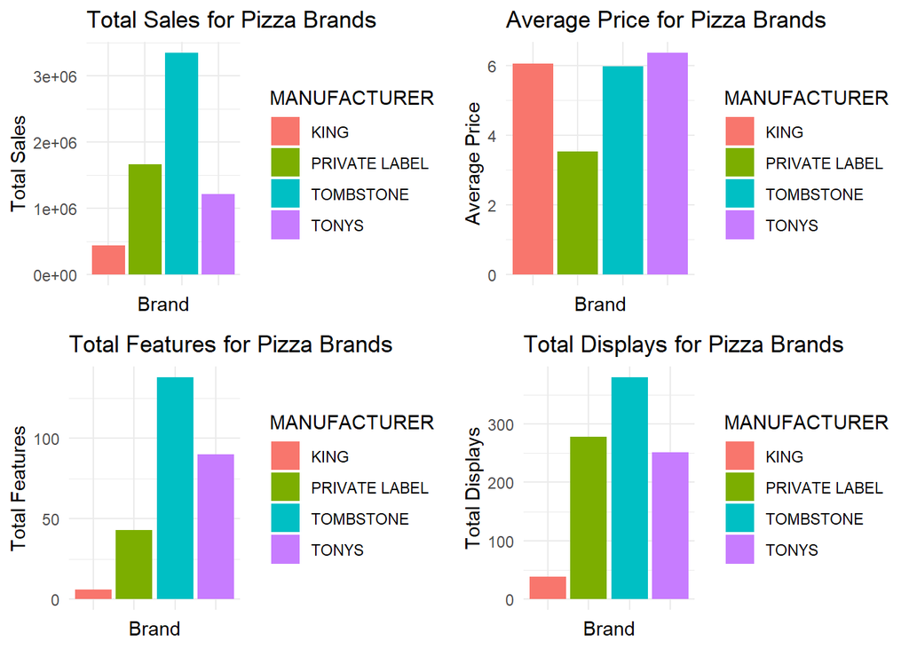

```r
p1 <- pizza %>% group_by(MANUFACTURER) %>%
  summarise(TOTAL_SALES=sum(SALES)) %>%
  ggplot()+
  geom_bar(aes(x=MANUFACTURER, y=TOTAL_SALES, fill=MANUFACTURER),
           stat="identity") +
   labs(title="Total Sales for Pizza Brands",
       x= "Brand",
       y="Total Sales")+
  theme(axis.ticks.x = element_blank(),
        axis.text.x = element_blank())

p2 <- pizza %>% group_by(MANUFACTURER) %>%
  summarise(AVG_PRICE=mean(W_AVG_PRICE)) %>%
  ggplot()+
  geom_bar(aes(x=MANUFACTURER, y=AVG_PRICE, fill=MANUFACTURER), stat="identity")+
    labs(title="Average Price for Pizza Brands",
       x= "Brand",
       y="Average Price")+
  theme(axis.ticks.x = element_blank(),
        axis.text.x = element_blank())

p3 <- pizza %>% group_by(MANUFACTURER) %>%
  summarise(TOTAL_FEATURES=sum(FEATURE)) %>%
  ggplot()+
  geom_bar(aes(x=MANUFACTURER, y=TOTAL_FEATURES, fill=MANUFACTURER),
           stat="identity")+
   labs(title="Total Features for Pizza Brands",
       x= "Brand",
       y="Total Features")+
  theme(axis.ticks.x = element_blank(),
        axis.text.x = element_blank())


p4 <- pizza %>% group_by(MANUFACTURER) %>%
  summarise(TOTAL_DISPLAYS=sum(DISPLAY)) %>%
  ggplot()+
  geom_bar(aes(x=MANUFACTURER, y=TOTAL_DISPLAYS, fill=MANUFACTURER),
           stat="identity")+
   labs(title="Total Displays for Pizza Brands",
       x= "Brand",
       y="Total Displays")+
  theme(axis.ticks.x = element_blank(),
        axis.text.x = element_blank())

grid.arrange(p1,p2,p3,p4,nrow=2)
```

The price-sales relationship is weaker in the frozen pizza category. Tombstone, King, and Tony’s have similar prices but Tombstone has more sales than King and Tony’s combined. This is more likely due to the difference in taste as consumers may prefer Tombstone’s pizza over others. However, Tombstone also has a much bigger number of feature promotions so that may also be a contributing factor.

In summary, frozen pizza consumers are less concerned with price. Although the three brands are sold at around the same price, Tombstone had more feature promotions which means that its base prices were typically more expensive than those of Tony’s and King. This also indicates the price perception of pizza consumers: at the same price, they may be more likely to buy the product which had the higher base price.

### Oral Hygiene

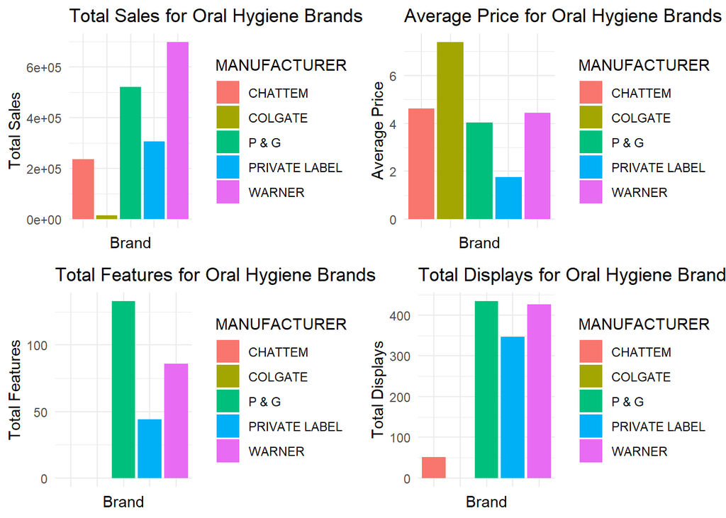

```r
p1 <- oral %>% group_by(MANUFACTURER) %>%
  summarise(TOTAL_SALES=sum(SALES)) %>%
  ggplot()+
  geom_bar(aes(x=MANUFACTURER, y=TOTAL_SALES, fill=MANUFACTURER),
           stat="identity")+
  labs(title="Total Sales for Oral Hygiene Brands",
       x= "Brand",
       y="Total Sales")+
  theme(axis.ticks.x = element_blank(),
        axis.text.x = element_blank())

p2 <- oral %>% group_by(MANUFACTURER) %>%
  summarise(AVG_PRICE=mean(W_AVG_PRICE)) %>%
  ggplot()+
  geom_bar(aes(x=MANUFACTURER, y=AVG_PRICE, fill=MANUFACTURER), stat="identity")+
    labs(title="Average Price for Oral Hygiene Brands",
       x= "Brand",
       y="Average Price")+
  theme(axis.ticks.x = element_blank(),
        axis.text.x = element_blank())

p3 <- oral %>% group_by(MANUFACTURER) %>%
  summarise(TOTAL_FEATURES=sum(FEATURE)) %>%
  ggplot()+
  geom_bar(aes(x=MANUFACTURER, y=TOTAL_FEATURES, fill=MANUFACTURER),
           stat="identity")+
   labs(title="Total Features for Oral Hygiene Brands",
       x= "Brand",
       y="Total Features")+
  theme(axis.ticks.x = element_blank(),
        axis.text.x = element_blank())

p4 <- oral %>% group_by(MANUFACTURER) %>%
  summarise(TOTAL_DISPLAYS=sum(DISPLAY)) %>%
  ggplot()+
  geom_bar(aes(x=MANUFACTURER, y=TOTAL_DISPLAYS, fill=MANUFACTURER),
           stat="identity")+
   labs(title="Total Displays for Oral Hygiene Brands",
       x= "Brand",
       y="Total Displays")+
  theme(axis.ticks.x = element_blank(),
        axis.text.x = element_blank())

grid.arrange(p1,p2,p3,p4,nrow=2)
```

In summary, oral care consumers are price sensitive and brand aware. They look for reliable brands with affordable prices and promotions.

# Model Implementation

## Variable Identification

We need the price of the competing brands for the SCAN*PRO model so we add a separate price column for the price of the closest competitor. We consider 2 firms to be in close competition if they have the closest sales figures. For Frito-Lay, the closest competitor is Snyder. For Quaker and Tony’s, it is the private label. For P&G, it is Warner. The final tables for each brand will look as follows:

```r
# Frito-Lay
price_1 <- snacks %>%
  filter(MANUFACTURER == "SNYDER S") %>%
  group_by(WEEK_END_DATE,UPSCALE,MAINSTREAM) %>%
  summarise(PRICE_COMP=weighted.mean(W_AVG_PRICE,TOTAL_UNITS))


snacks_FL <- snacks %>%
  filter(MANUFACTURER == "FRITO LAY") %>%
  left_join(price_1, by=c("WEEK_END_DATE","UPSCALE","MAINSTREAM"))


# Kellogg


price_2 <- cereal %>%
  filter(MANUFACTURER == "PRIVATE LABEL") %>%
  group_by(WEEK_END_DATE,UPSCALE,MAINSTREAM) %>%
  summarise(PRICE_COMP=weighted.mean(W_AVG_PRICE,TOTAL_UNITS))


cereal_Q <- cereal %>%
  filter(MANUFACTURER == "QUAKER") %>%
  left_join(price_2, by=c("WEEK_END_DATE","UPSCALE","MAINSTREAM"))

# Tony's

price_3 <- pizza %>%
  filter(MANUFACTURER == "PRIVATE LABEL") %>%
  group_by(WEEK_END_DATE,UPSCALE,MAINSTREAM) %>%
  summarise(PRICE_COMP=weighted.mean(W_AVG_PRICE,TOTAL_UNITS))


pizza_TNY <- pizza %>%
  filter(MANUFACTURER == "TONYS") %>%
  left_join(price_3, by=c("WEEK_END_DATE","UPSCALE","MAINSTREAM"))

# P&G

price_4 <- oral %>%
  filter(MANUFACTURER == "WARNER") %>%
  group_by(WEEK_END_DATE,UPSCALE,MAINSTREAM) %>%
  summarise(PRICE_COMP=weighted.mean(W_AVG_PRICE,TOTAL_UNITS))


oral_PG <- oral %>%
  filter(MANUFACTURER == "P & G") %>%
  left_join(price_4, by=c("WEEK_END_DATE","UPSCALE","MAINSTREAM"))

head(snacks_FL) %>% kbl(caption="Frito Lay") %>%   kable_paper("hover", full_width = F)
```

Frito Lay

| WEEK_END_DATE | MANUFACTURER | UPSCALE | MAINSTREAM | W_AVG_PRICE | TOTAL_UNITS | SALES | DISPLAY | FEATURE | DISPL_FEATURE | PRICE_COMP |
| --- | --- | --- | --- | --- | --- | --- | --- | --- | --- | --- |
| 2009-01-14 | FRITO LAY | 0 | 0 | 2.638235 | 170 | 448.50 | 0 | 0 | 0 | 2.506818 |
| 2009-01-14 | FRITO LAY | 0 | 1 | 2.653154 | 1319 | 3499.51 | 1 | 0 | 0 | 2.494835 |
| 2009-01-14 | FRITO LAY | 1 | 0 | 2.642766 | 1139 | 3010.11 | 0 | 0 | 0 | 2.488201 |
| 2009-01-21 | FRITO LAY | 0 | 0 | 2.637945 | 146 | 385.14 | 0 | 0 | 0 | 2.493605 |
| 2009-01-21 | FRITO LAY | 0 | 1 | 2.659332 | 1363 | 3624.67 | 0 | 0 | 0 | 2.489492 |
| 2009-01-21 | FRITO LAY | 1 | 0 | 2.647026 | 1103 | 2919.67 | 0 | 0 | 0 | 2.483042 |

```r
head(cereal_Q) %>% kbl(caption="Quaker") %>%   kable_paper("hover", full_width = F)
```

Quaker

| WEEK_END_DATE | MANUFACTURER | UPSCALE | MAINSTREAM | W_AVG_PRICE | TOTAL_UNITS | SALES | DISPLAY | FEATURE | DISPL_FEATURE | PRICE_COMP |
| --- | --- | --- | --- | --- | --- | --- | --- | --- | --- | --- |
| 2009-01-14 | QUAKER | 0 | 0 | 2.014229 | 2478 | 4991.26 | 1 | 0 | 0 | 1.873877 |
| 2009-01-14 | QUAKER | 0 | 1 | 2.004943 | 5213 | 10451.77 | 1 | 0 | 0 | 1.895157 |
| 2009-01-14 | QUAKER | 1 | 0 | 2.007789 | 2334 | 4686.18 | 1 | 0 | 0 | 1.898763 |
| 2009-01-21 | QUAKER | 0 | 0 | 2.545727 | 1079 | 2746.84 | 1 | 0 | 0 | 1.902834 |
| 2009-01-21 | QUAKER | 0 | 1 | 2.627902 | 2297 | 6036.29 | 1 | 0 | 0 | 1.915642 |
| 2009-01-21 | QUAKER | 1 | 0 | 2.650748 | 1056 | 2799.19 | 1 | 0 | 0 | 1.923709 |

```r
head(pizza_TNY) %>% kbl(caption="Tony's") %>%   kable_paper("hover", full_width = F)
```

Tony’s

| WEEK_END_DATE | MANUFACTURER | UPSCALE | MAINSTREAM | W_AVG_PRICE | TOTAL_UNITS | SALES | DISPLAY | FEATURE | DISPL_FEATURE | PRICE_COMP |
| --- | --- | --- | --- | --- | --- | --- | --- | --- | --- | --- |
| 2009-01-14 | TONYS | 0 | 0 | 6.529178 | 73 | 476.63 | 1 | 0 | 0 | 3.304451 |
| 2009-01-14 | TONYS | 0 | 1 | 6.623681 | 470 | 3113.13 | 1 | 0 | 0 | 3.300542 |
| 2009-01-14 | TONYS | 1 | 0 | 6.629568 | 278 | 1843.02 | 1 | 0 | 0 | 3.292855 |
| 2009-01-21 | TONYS | 0 | 0 | 6.597500 | 48 | 316.68 | 1 | 0 | 0 | 3.291202 |
| 2009-01-21 | TONYS | 0 | 1 | 6.636752 | 428 | 2840.53 | 1 | 0 | 0 | 3.299108 |
| 2009-01-21 | TONYS | 1 | 0 | 6.616608 | 283 | 1872.50 | 1 | 0 | 0 | 3.301163 |

```r
head(oral_PG) %>% kbl(caption="P&G") %>%   kable_paper("hover", full_width = F)
```

P&G

| WEEK_END_DATE | MANUFACTURER | UPSCALE | MAINSTREAM | W_AVG_PRICE | TOTAL_UNITS | SALES | DISPLAY | FEATURE | DISPL_FEATURE | PRICE_COMP |
| --- | --- | --- | --- | --- | --- | --- | --- | --- | --- | --- |
| 2009-01-14 | P & G | 0 | 0 | 3.684914 | 175 | 644.86 | 1 | 0 | 0 | 4.893401 |
| 2009-01-14 | P & G | 0 | 1 | 3.492964 | 739 | 2581.30 | 1 | 0 | 0 | 4.585602 |
| 2009-01-14 | P & G | 1 | 0 | 3.243022 | 503 | 1631.24 | 1 | 0 | 0 | 4.872698 |
| 2009-01-21 | P & G | 0 | 0 | 3.594803 | 152 | 546.41 | 1 | 0 | 0 | 4.905862 |
| 2009-01-21 | P & G | 0 | 1 | 3.392961 | 743 | 2520.97 | 1 | 0 | 0 | 4.562373 |
| 2009-01-21 | P & G | 1 | 0 | 3.322857 | 441 | 1465.38 | 1 | 0 | 0 | 4.874211 |

## Seasonality

It is important to decompose the time-series sales data for each product across all three store types to determine whether sales exhibit any form of seasonality. Snacks, cereal, pizza, and oral hygiene products are not expected to exhibit monthly or quarterly seasonality but rather weekly seasonality since they are viewed as necessities (groceries). We therefore first examine the significance of a weakly seasonality factor and if significant, we create a dummy variable for each week number (1 to 52) which we later use in the model specification.

### Frito-Lay

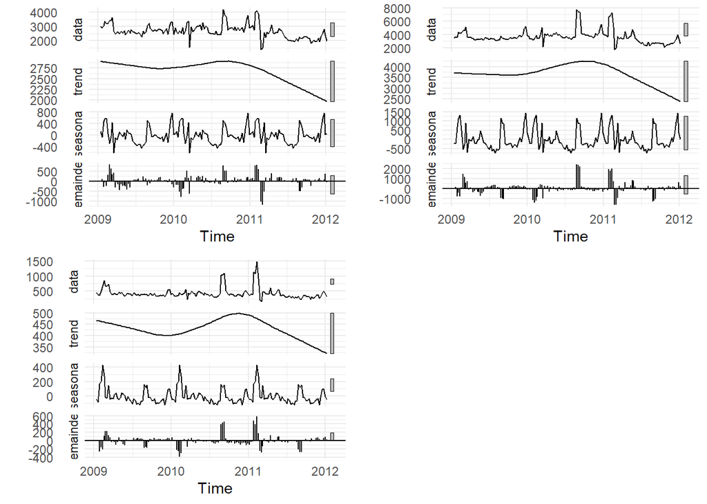

```r
# Upscale
FL_upscale <- snacks_FL %>%
  filter(UPSCALE==1) %>%
  ts(frequency = 52, start=decimal_date(ymd("2009-01-14")))

ts_FL_upscale <- FL_upscale[,7]
p1<-ts_FL_upscale %>%
  stl(s.window = "period") %>% autoplot(title = "Decomposition for Sales (Upscale Stores)")

# Mainstream
FL_mainstream <- snacks_FL %>%
  filter(MAINSTREAM==1) %>%
  ts(frequency = 52, start=decimal_date(ymd("2009-01-14")))

plot_sales2 <- FL_mainstream[,7]
p2<-plot_sales2 %>% stl(s.window = "period") %>% autoplot(title = "Decomposition for Sales (Mainstream Stores)")

# Value
FL_value <- snacks_FL %>%
  filter(MAINSTREAM==0 & UPSCALE==0) %>%
  ts(frequency = 52, start=decimal_date(ymd("2009-01-14")))

plot_sales3 <- FL_value[,7]
p3<-plot_sales3 %>% stl(s.window = "period") %>% autoplot(title = "Decomposition for Sales (Value Stores)")
grid.arrange(p1,p2,p3,nrow=2)
```

For Frito-Lay, weekly seasonality is insignificant for mainstream and upscale stores but is quite significant for value stores. It is therefore useful to integrate a seasonality factor into the model.

```r
snacks_FL <- snacks_FL %>%
  mutate(WEEK_NUM=as.character(week(WEEK_END_DATE))) %>%
  dummy_cols(select_columns="WEEK_NUM", remove_first_dummy = TRUE) %>%
  rename(PRICE_BRAND=W_AVG_PRICE) %>%
  select(-c(WEEK_END_DATE,TOTAL_UNITS))

head(snacks_FL[,1:12]) %>% kbl(caption="Frito Lay") %>%   kable_paper("hover", full_width = F)
```

Frito Lay

| MANUFACTURER | UPSCALE | MAINSTREAM | PRICE_BRAND | SALES | DISPLAY | FEATURE | DISPL_FEATURE | PRICE_COMP | WEEK_NUM | WEEK_NUM_2 | WEEK_NUM_3 |
| --- | --- | --- | --- | --- | --- | --- | --- | --- | --- | --- | --- |
| FRITO LAY | 0 | 0 | 2.638235 | 448.50 | 0 | 0 | 0 | 2.506818 | 2 | 1 | 0 |
| FRITO LAY | 0 | 1 | 2.653154 | 3499.51 | 1 | 0 | 0 | 2.494835 | 2 | 1 | 0 |
| FRITO LAY | 1 | 0 | 2.642766 | 3010.11 | 0 | 0 | 0 | 2.488201 | 2 | 1 | 0 |
| FRITO LAY | 0 | 0 | 2.637945 | 385.14 | 0 | 0 | 0 | 2.493605 | 3 | 0 | 1 |
| FRITO LAY | 0 | 1 | 2.659332 | 3624.67 | 0 | 0 | 0 | 2.489492 | 3 | 0 | 1 |
| FRITO LAY | 1 | 0 | 2.647026 | 2919.67 | 0 | 0 | 0 | 2.483042 | 3 | 0 | 1 |

### Quaker

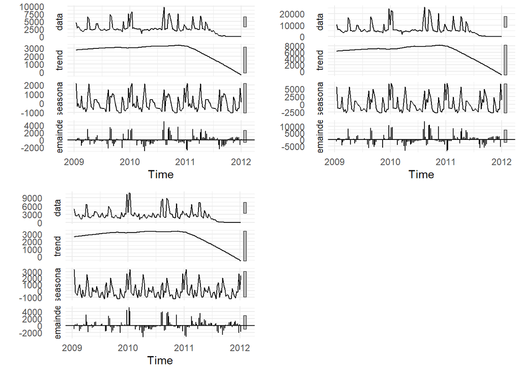

```r
# Upscale
cereal_Q <- rename(cereal_Q,PRICE_BRAND=W_AVG_PRICE)
Q_upscale <- cereal_Q %>%
  filter(UPSCALE==1) %>%
  ts(frequency = 52, start=decimal_date(ymd("2009-01-14")))

plot_sales1 <- Q_upscale[,7]
p1 <- plot_sales1 %>%
  stl(s.window = "period") %>% autoplot(title = "Decomposition for Sales (Upscale Stores)")

# Mainstream
Q_mainstream <- cereal_Q %>%
  filter(MAINSTREAM==1) %>%
  ts(frequency = 52, start=decimal_date(ymd("2009-01-14")))

plot_sales2 <- Q_mainstream[,7]
p2 <- plot_sales2 %>% stl(s.window = "period") %>% autoplot(title = "Decomposition for Sales (Mainstream Stores)")

# Value
Q_value <- cereal_Q %>%
  filter(MAINSTREAM==0 & UPSCALE==0) %>%
  ts(frequency = 52, start=decimal_date(ymd("2009-01-14")))

plot_sales3 <- Q_value[,7]
p3<-plot_sales3 %>% stl(s.window = "period") %>% autoplot(title = "Decomposition for Sales (Value Stores)")

grid.arrange(p1,p2,p3,nrow=2)
```

### Tony’s

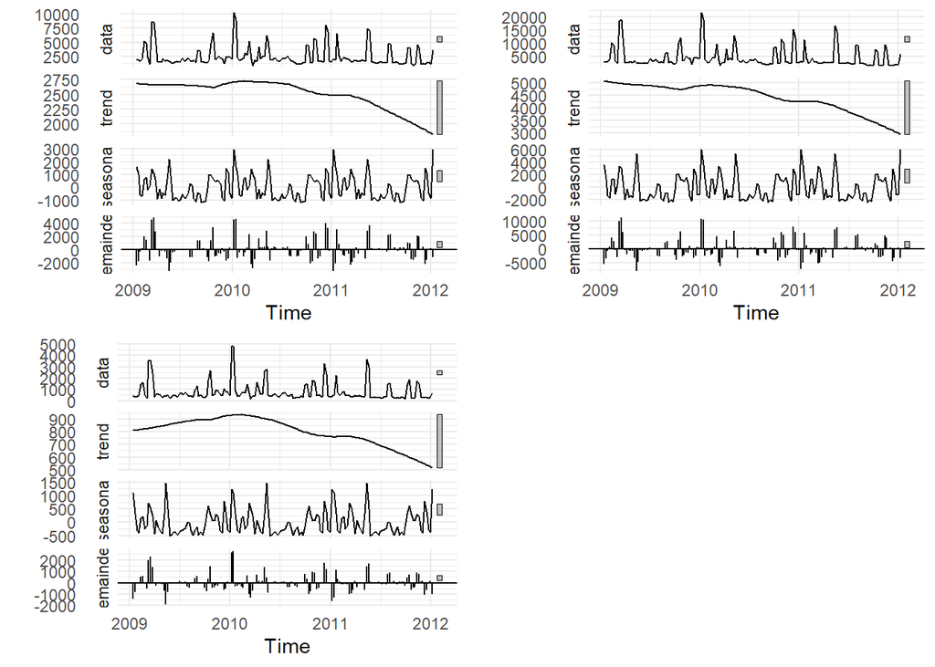

```r
# Upscale
TNY_upscale <- pizza_TNY %>%
  filter(UPSCALE==1) %>%
  ts(frequency = 52, start=decimal_date(ymd("2009-01-14")))

plot_sales1 <- TNY_upscale[,7]
p1<-plot_sales1 %>%
  stl(s.window = "period") %>% autoplot(title = "Decomposition for Sales (Upscale Stores)")

# Mainstream
TNY_mainstream <- pizza_TNY %>%
  filter(MAINSTREAM==1) %>%
  ts(frequency = 52, start=decimal_date(ymd("2009-01-14")))

plot_sales2 <- TNY_mainstream[,7]
p2<-plot_sales2 %>% stl(s.window = "period") %>% autoplot(title = "Decomposition for Sales (Mainstream Stores)")

# Value
TNY_value <- pizza_TNY %>%
  filter(MAINSTREAM==0 & UPSCALE==0) %>%
  ts(frequency = 52, start=decimal_date(ymd("2009-01-14")))

plot_sales3 <- TNY_value[,7]
p3<-plot_sales3 %>% stl(s.window = "period") %>% autoplot(title = "Decomposition for Sales (Value Stores)")

grid.arrange(p1,p2,p3,nrow=2)
```

Tony’s exhibits very strong weekly seasonality across all store types so we integrate seasonality into its model.

```r
pizza_TNY <- pizza_TNY %>%
  mutate(WEEK_NUM=as.character(week(WEEK_END_DATE))) %>%
  dummy_cols(select_columns="WEEK_NUM", remove_first_dummy = TRUE) %>%
  rename(PRICE_BRAND=W_AVG_PRICE) %>%
  select(-c(WEEK_END_DATE,TOTAL_UNITS))

head(pizza_TNY[,1:12]) %>% kbl(caption="Tony's") %>%   kable_paper("hover", full_width = F)
```

Tony’s

| MANUFACTURER | UPSCALE | MAINSTREAM | PRICE_BRAND | SALES | DISPLAY | FEATURE | DISPL_FEATURE | PRICE_COMP | WEEK_NUM | WEEK_NUM_2 | WEEK_NUM_3 |
| --- | --- | --- | --- | --- | --- | --- | --- | --- | --- | --- | --- |
| TONYS | 0 | 0 | 6.529178 | 476.63 | 1 | 0 | 0 | 3.304451 | 2 | 1 | 0 |
| TONYS | 0 | 1 | 6.623681 | 3113.13 | 1 | 0 | 0 | 3.300542 | 2 | 1 | 0 |
| TONYS | 1 | 0 | 6.629568 | 1843.02 | 1 | 0 | 0 | 3.292855 | 2 | 1 | 0 |
| TONYS | 0 | 0 | 6.597500 | 316.68 | 1 | 0 | 0 | 3.291202 | 3 | 0 | 1 |
| TONYS | 0 | 1 | 6.636752 | 2840.53 | 1 | 0 | 0 | 3.299108 | 3 | 0 | 1 |
| TONYS | 1 | 0 | 6.616608 | 1872.50 | 1 | 0 | 0 | 3.301163 | 3 | 0 | 1 |

### P&G

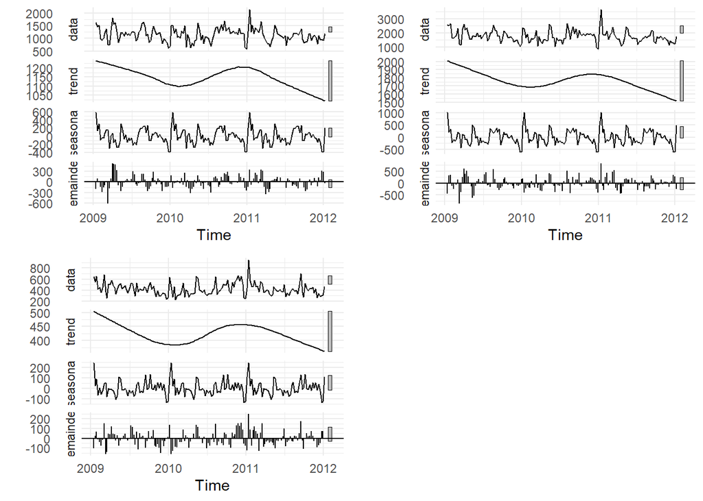

```r
# Upscale
PG_upscale <- oral_PG %>%
  filter(UPSCALE==1) %>%
  ts(frequency = 52, start=decimal_date(ymd("2009-01-14")))

plot_sales1 <- PG_upscale[,7]
p1<-plot_sales1 %>%
  stl(s.window = "period") %>% autoplot(title = "Decomposition for Sales (Upscale Stores)")

# Mainstream
PG_mainstream <- oral_PG %>%
  filter(MAINSTREAM==1) %>%
  ts(frequency = 52, start=decimal_date(ymd("2009-01-14")))

plot_sales2 <- PG_mainstream[,7]
p2<-plot_sales2 %>% stl(s.window = "period") %>% autoplot(title = "Decomposition for Sales (Mainstream Stores)")

# Value
PG_value <- oral_PG %>%
  filter(MAINSTREAM==0 & UPSCALE==0) %>%
  ts(frequency = 52, start=decimal_date(ymd("2009-01-14")))

plot_sales3 <- PG_value[,7]
p3<-plot_sales3 %>% stl(s.window = "period") %>% autoplot(title = "Decomposition for Sales (Value Stores)")

grid.arrange(p1,p2,p3,nrow=2)
```

P&G also exhibits very strong weekly seasonality across all store types so we integrate seasonality into its model.

```r
oral_PG <- oral_PG %>%
  mutate(WEEK_NUM=as.character(week(WEEK_END_DATE))) %>%
  dummy_cols(select_columns="WEEK_NUM", remove_first_dummy = TRUE) %>%
  rename(PRICE_BRAND=W_AVG_PRICE) %>%
  select(-c(WEEK_END_DATE,TOTAL_UNITS))

head(oral_PG[,1:12]) %>% kbl(caption="P&G") %>%   kable_paper("hover", full_width = F)
```

P&G

| MANUFACTURER | UPSCALE | MAINSTREAM | PRICE_BRAND | SALES | DISPLAY | FEATURE | DISPL_FEATURE | PRICE_COMP | WEEK_NUM | WEEK_NUM_2 | WEEK_NUM_3 |
| --- | --- | --- | --- | --- | --- | --- | --- | --- | --- | --- | --- |
| P & G | 0 | 0 | 3.684914 | 644.86 | 1 | 0 | 0 | 4.893401 | 2 | 1 | 0 |
| P & G | 0 | 1 | 3.492964 | 2581.30 | 1 | 0 | 0 | 4.585602 | 2 | 1 | 0 |
| P & G | 1 | 0 | 3.243022 | 1631.24 | 1 | 0 | 0 | 4.872698 | 2 | 1 | 0 |
| P & G | 0 | 0 | 3.594803 | 546.41 | 1 | 0 | 0 | 4.905862 | 3 | 0 | 1 |
| P & G | 0 | 1 | 3.392961 | 2520.97 | 1 | 0 | 0 | 4.562373 | 3 | 0 | 1 |
| P & G | 1 | 0 | 3.322857 | 1465.38 | 1 | 0 | 0 | 4.874211 | 3 | 0 | 1 |

## SCAN*PRO Model

For any brands, the SCAN*PRO model specification will be as follows:

$\ln({SALES_{BRAND}})=\beta_0+\beta_1\ln(PRICE\_BRAND)+\beta_2\ln(PRICE\_COMP)+\theta_1\ln(Feature\_Effect)+\theta_2\ln(Display\_Effect)+\theta_3\ln(Feature\&Display_Effect)+\gamma_1\ln(Upscale\_Effect)+\gamma_2\ln(Mainstream\_Effect)+\alpha_i\sum_{n=2}^{52}\ln(Week\_Number\_Effect)$

where:

$\beta_1$ captures the own price elasticity of the brand

$\beta_2$ captures the cross price elasticity of the brand with its competitor

$\theta_1,\theta_2,and \: \theta_3$ capture the feature, display, and feature-display multiplier respectively

$\gamma_1 \: and \: \gamma_2$ capture the difference in store type sales

$\alpha_i$ captures the weekly seasonality

We take the natural logarithm of each numeric variable except the dummy variables.

### Frito Lay

```r
# take logarithm of each variable, excpet BINARY
snacks_FL$log_sales <- log(snacks_FL$SALES)
snacks_FL$log_our_price <- log(snacks_FL$PRICE_BRAND)
snacks_FL$log_comp_price <-log(snacks_FL$PRICE_COMP)

# estimate linear model
FL <- snacks_FL %>%
  select(-c(SALES,PRICE_BRAND,PRICE_COMP,WEEK_NUM,MANUFACTURER))

scanpro_FL <- lm(log_sales~.,data=FL)
summary(scanpro_FL)
```

```
##
## Call:
## lm(formula = log_sales ~ ., data = FL)
##
## Residuals:
##      Min       1Q   Median       3Q      Max
## -0.74493 -0.08961  0.01428  0.08180  0.56195
##
## Coefficients:
##                  Estimate Std. Error t value Pr(>|t|)
## (Intercept)     7.7741346  0.1607612  48.358  < 2e-16 ***
## UPSCALE         1.8706567  0.0176192 106.172  < 2e-16 ***
## MAINSTREAM      2.1556275  0.0186649 115.491  < 2e-16 ***
## DISPLAY         0.0398438  0.0194939   2.044 0.041602 *
## FEATURE         0.0470999  0.1656718   0.284 0.776327
## DISPL_FEATURE   0.0791777  0.1700894   0.466 0.641817
## WEEK_NUM_2     -0.0218114  0.0735285  -0.297 0.766893
## WEEK_NUM_3     -0.0796009  0.0735123  -1.083 0.279524
## WEEK_NUM_4     -0.0906320  0.0750015  -1.208 0.227591
## WEEK_NUM_5     -0.0252705  0.0755428  -0.335 0.738160
## WEEK_NUM_6      0.0846239  0.0755398   1.120 0.263262
## WEEK_NUM_7     -0.0209837  0.0774069  -0.271 0.786464
## WEEK_NUM_8     -0.2161000  0.0743214  -2.908 0.003840 **
## WEEK_NUM_9     -0.1743847  0.0740662  -2.354 0.019022 *
## WEEK_NUM_10     0.1704914  0.0742335   2.297 0.022141 *
## WEEK_NUM_11    -0.2080587  0.0737376  -2.822 0.005011 **
## WEEK_NUM_12    -0.0288310  0.0736776  -0.391 0.695769
## WEEK_NUM_13    -0.0494505  0.0735046  -0.673 0.501483
## WEEK_NUM_14     0.0023019  0.0734770   0.031 0.975023
## WEEK_NUM_15    -0.1271646  0.0754593  -1.685 0.092711 .
## WEEK_NUM_16    -0.0400168  0.0739522  -0.541 0.588722
## WEEK_NUM_17    -0.0674126  0.0737133  -0.915 0.360980
## WEEK_NUM_18    -0.0124127  0.0736450  -0.169 0.866236
## WEEK_NUM_19     0.0072116  0.0734543   0.098 0.921839
## WEEK_NUM_20    -0.0277777  0.0746757  -0.372 0.710102
## WEEK_NUM_21    -0.0896202  0.0753088  -1.190 0.234723
## WEEK_NUM_22    -0.0714982  0.0735821  -0.972 0.331784
## WEEK_NUM_23    -0.0001795  0.0733176  -0.002 0.998048
## WEEK_NUM_24    -0.0592855  0.0732535  -0.809 0.418802
## WEEK_NUM_25    -0.0895773  0.0733115  -1.222 0.222459
```

[output cut: 20 more lines]

```
## WEEK_NUM_46    -0.0320649  0.0730741  -0.439 0.661038
## WEEK_NUM_47     0.0342550  0.0735427   0.466 0.641618
## WEEK_NUM_48    -0.1138442  0.0732707  -1.554 0.121018
## WEEK_NUM_49     0.0741166  0.0732628   1.012 0.312302
## WEEK_NUM_50     0.2442898  0.0729344   3.349 0.000885 ***
## WEEK_NUM_51     0.3150583  0.0729407   4.319 1.97e-05 ***
## WEEK_NUM_52     0.0660908  0.0731811   0.903 0.366998
## log_our_price  -1.7424831  0.1337473 -13.028  < 2e-16 ***
## log_comp_price  0.0848076  0.1069376   0.793 0.428204
## ---
## Signif. codes:  0 '***' 0.001 '**' 0.01 '*' 0.05 '.' 0.1 ' ' 1
##
## Residual standard error: 0.1547 on 409 degrees of freedom
## Multiple R-squared:  0.9788, Adjusted R-squared:  0.9757
## F-statistic: 324.8 on 58 and 409 DF,  p-value: < 2.2e-16
```

### Tony’s

```r
# take logarithm of each variable, excePt BINARY
pizza_TNY$log_sales <- log(pizza_TNY$SALES)
pizza_TNY$log_our_price <- log(pizza_TNY$PRICE_BRAND)
pizza_TNY$log_comp_price <-log(pizza_TNY$PRICE_COMP)

# estimate linear model
TNY <- pizza_TNY %>%
  select(-c(SALES,PRICE_BRAND,PRICE_COMP,WEEK_NUM,MANUFACTURER))

scanpro_TNY <- lm(log_sales~.,data=TNY)
summary(scanpro_TNY)
```

```
##
## Call:
## lm(formula = log_sales ~ ., data = TNY)
##
## Residuals:
##      Min       1Q   Median       3Q      Max
## -1.01497 -0.12365 -0.01281  0.12945  0.78626
##
## Coefficients: (1 not defined because of singularities)
##                  Estimate Std. Error t value Pr(>|t|)
## (Intercept)    11.3712119  0.3723475  30.539  < 2e-16 ***
## UPSCALE         1.3017113  0.0275784  47.200  < 2e-16 ***
## MAINSTREAM      1.8130833  0.0306601  59.135  < 2e-16 ***
## DISPLAY        -0.0266438  0.0301274  -0.884 0.377013
## FEATURE         0.2786172  0.0616437   4.520 8.11e-06 ***
## DISPL_FEATURE          NA         NA      NA       NA
## WEEK_NUM_2      0.1193736  0.1140307   1.047 0.295783
## WEEK_NUM_3      0.0889511  0.1143664   0.778 0.437151
## WEEK_NUM_4     -0.3746573  0.1157269  -3.237 0.001304 **
## WEEK_NUM_5     -0.0082227  0.1171022  -0.070 0.944054
## WEEK_NUM_6      0.1681742  0.1181155   1.424 0.155261
## WEEK_NUM_7     -0.0585279  0.1179558  -0.496 0.620030
## WEEK_NUM_8      0.2008255  0.1187757   1.691 0.091636 .
## WEEK_NUM_9     -0.1094434  0.1167405  -0.937 0.349057
## WEEK_NUM_10     0.1196542  0.1171058   1.022 0.307497
## WEEK_NUM_11    -0.2222237  0.1162897  -1.911 0.056708 .
## WEEK_NUM_12    -0.0702302  0.1163087  -0.604 0.546294
## WEEK_NUM_13    -0.1538517  0.1182763  -1.301 0.194064
## WEEK_NUM_14    -0.0557001  0.1175960  -0.474 0.635997
## WEEK_NUM_15     0.0825326  0.1175219   0.702 0.482907
## WEEK_NUM_16     0.1124123  0.1176608   0.955 0.339942
## WEEK_NUM_17    -0.0611643  0.1188558  -0.515 0.607103
## WEEK_NUM_18     0.1199420  0.1161215   1.033 0.302260
## WEEK_NUM_19     0.1491822  0.1171809   1.273 0.203706
## WEEK_NUM_20     0.0507852  0.1185653   0.428 0.668635
## WEEK_NUM_21    -0.2950489  0.1197134  -2.465 0.014125 *
## WEEK_NUM_22    -0.1739854  0.1197540  -1.453 0.147029
## WEEK_NUM_23    -0.0893835  0.1209780  -0.739 0.460426
## WEEK_NUM_24    -0.1961373  0.1212219  -1.618 0.106431
## WEEK_NUM_25    -0.2999261  0.1213209  -2.472 0.013834 *
```

[output cut: 20 more lines]

```
## WEEK_NUM_46     0.0811657  0.1166887   0.696 0.487089
## WEEK_NUM_47    -0.0256618  0.1180406  -0.217 0.828006
## WEEK_NUM_48    -0.2452138  0.1179275  -2.079 0.038205 *
## WEEK_NUM_49     0.1332010  0.1177335   1.131 0.258557
## WEEK_NUM_50     0.0944445  0.1143389   0.826 0.409282
## WEEK_NUM_51     0.0499305  0.1159262   0.431 0.666906
## WEEK_NUM_52    -0.1170952  0.1159742  -1.010 0.313251
## log_our_price  -2.9604608  0.1551347 -19.083  < 2e-16 ***
## log_comp_price  0.3722175  0.2110644   1.764 0.078557 .
## ---
## Signif. codes:  0 '***' 0.001 '**' 0.01 '*' 0.05 '.' 0.1 ' ' 1
##
## Residual standard error: 0.2404 on 410 degrees of freedom
## Multiple R-squared:  0.9482, Adjusted R-squared:  0.941
## F-statistic: 131.6 on 57 and 410 DF,  p-value: < 2.2e-16
```

Coefficients which are significant at the 95% confidence level are brand’s price, upscale, mainstream, and feature.

### P&G

```r
# take logarithm of each variable, excpet "Display"
oral_PG$log_sales <- log(oral_PG$SALES)
oral_PG$log_our_price <- log(oral_PG$PRICE_BRAND)
oral_PG$log_comp_price <-log(oral_PG$PRICE_COMP)

# estimate linear model
PG <- oral_PG %>%
  select(-c(SALES,PRICE_BRAND,PRICE_COMP,WEEK_NUM,MANUFACTURER))

scanpro_PG <- lm(log_sales~.,data=PG)
summary(scanpro_PG)
```

```
##
## Call:
## lm(formula = log_sales ~ ., data = PG)
##
## Residuals:
##      Min       1Q   Median       3Q      Max
## -0.53522 -0.10671  0.00128  0.11072  0.49038
##
## Coefficients:
##                 Estimate Std. Error t value Pr(>|t|)
## (Intercept)     6.314711   0.279522  22.591  < 2e-16 ***
## UPSCALE         0.990348   0.020850  47.499  < 2e-16 ***
## MAINSTREAM      1.412306   0.021088  66.971  < 2e-16 ***
## DISPLAY         0.073232   0.036811   1.989 0.047323 *
## FEATURE         0.018740   0.039951   0.469 0.639275
## DISPL_FEATURE   0.113925   0.041601   2.739 0.006441 **
## WEEK_NUM_2      0.261232   0.084169   3.104 0.002044 **
## WEEK_NUM_3      0.017835   0.086207   0.207 0.836203
## WEEK_NUM_4      0.176481   0.086606   2.038 0.042218 *
## WEEK_NUM_5     -0.116034   0.088761  -1.307 0.191857
## WEEK_NUM_6     -0.048228   0.088653  -0.544 0.586729
## WEEK_NUM_7     -0.066028   0.088327  -0.748 0.455167
## WEEK_NUM_8      0.008200   0.088015   0.093 0.925819
## WEEK_NUM_9      0.071622   0.087093   0.822 0.411349
## WEEK_NUM_10    -0.059867   0.084786  -0.706 0.480532
## WEEK_NUM_11    -0.425741   0.084956  -5.011 8.06e-07 ***
## WEEK_NUM_12     0.008259   0.087548   0.094 0.924884
## WEEK_NUM_13    -0.055552   0.086785  -0.640 0.522461
## WEEK_NUM_14    -0.113546   0.087429  -1.299 0.194772
## WEEK_NUM_15    -0.120611   0.087227  -1.383 0.167502
## WEEK_NUM_16    -0.236273   0.086666  -2.726 0.006681 **
## WEEK_NUM_17    -0.253519   0.087624  -2.893 0.004017 **
## WEEK_NUM_18    -0.117655   0.088243  -1.333 0.183172
## WEEK_NUM_19     0.018111   0.085802   0.211 0.832930
## WEEK_NUM_20     0.010020   0.084735   0.118 0.905928
## WEEK_NUM_21    -0.082456   0.087372  -0.944 0.345858
## WEEK_NUM_22    -0.053461   0.087744  -0.609 0.542676
## WEEK_NUM_23    -0.183100   0.089376  -2.049 0.041134 *
## WEEK_NUM_24    -0.098663   0.087372  -1.129 0.259462
## WEEK_NUM_25    -0.196595   0.086270  -2.279 0.023192 *
```

[output cut: 20 more lines]

```
## WEEK_NUM_46    -0.044104   0.092034  -0.479 0.632038
## WEEK_NUM_47    -0.147798   0.089054  -1.660 0.097753 .
## WEEK_NUM_48    -0.309176   0.086061  -3.593 0.000367 ***
## WEEK_NUM_49    -0.071597   0.087446  -0.819 0.413405
## WEEK_NUM_50    -0.176836   0.087500  -2.021 0.043931 *
## WEEK_NUM_51    -0.457104   0.087841  -5.204 3.10e-07 ***
## WEEK_NUM_52    -0.494379   0.086566  -5.711 2.16e-08 ***
## log_our_price  -0.344885   0.107016  -3.223 0.001371 **
## log_comp_price  0.120106   0.144677   0.830 0.406929
## ---
## Signif. codes:  0 '***' 0.001 '**' 0.01 '*' 0.05 '.' 0.1 ' ' 1
##
## Residual standard error: 0.1783 on 409 degrees of freedom
## Multiple R-squared:  0.9335, Adjusted R-squared:  0.924
## F-statistic: 98.94 on 58 and 409 DF,  p-value: < 2.2e-16
```

# Conclusion

No significant effect was found for feature promotions on Frito Lay’s sales while display promotions were found to increase sales by just 4% on average. This may be indicative that promotions are perhaps not the answer to Frito Lay’s marketing problem. Selling their products in mainstream and upscale stores has a significant upward effect on their sales, and they develop a strategy that concentrates on selling to those stores more than value stores.

Feature promotions were found to be very effective at increasing frozen pizza sales for Tony’s so they should definitely roll out more price-reduction promotions to gain market share and catch up to Tombstone.

Display-feature promotions (e.g: discounted bundles) were found to be most effective for P&G products so they should focus on these promotions to increase sales.